# Double Pendulum Coding Essay

```
Ellie Bacon & Joanna Nowakowska
05/04/21
```

## Introduction

The purpose of this project is to explore a double pendulum simulation. First, we start with a simulation of a single pendulum (Exercise 8.4) using the fourth order Runge-Kutta methods to solve the ODE equations. Then, in the main part of the project we present a full math derivation of a double pendulum to obtain the equations for potential, kinetic and total energies as well as angles and velocities for each ‘part’ of a double pendulum. Through the graphs of energies versus time we check if the energy conservation law applies. Angle vs time and velocity vs angle graphs enable better visualization of the whole motion. In the research part of the code we explored how mass and length changes affects the energy as well as the motion in time.

A double pendulum explored in this project is a pendulum with another pendulum attached to its end. The motion of a double pendulum follows a set of coupled ordinary differential equations presented in the main part of the code. We followed the assumption that both limbs of the pendulum had equal lengths and masses. The motion of the double pendulum is chaotic and experience nonlinear oscillations that shows a sensitive dependence on initial conditions. A picture of a double pendulum is presented below:

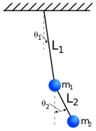

( https://en.wikipedia.org/wiki/Double_pendulum#/media/File:Double-Pendulum.svg )

## Single Pendulum

Before we jump into the double pendulum problem, we first need to understand the simple, single pendulum. We first imported all of the standard libaries and defined our constants and parameters. Through this code we learned the Runge-kutta method of evaluating differential equations. We plan to continue using the Runge-kutta method to evaluate our double pendulum problem as well.

For small displacements, a pendulum is a simple harmonic oscillator. A simple pendulum is defined to have an object that has a small mass, also known as the pendulum bob, which is suspended from a light wire or string, such as shown in the figure below. Exploring the simple pendulum a bit further, we can discover the conditions under which it performs simple harmonic motion, and we can derive an interesting expression for its period.

The only things that affect the period of a simple pendulum are its length and the acceleration due to gravity. The period is completely independent of other factors, such as mass. As with simple harmonic oscillators, the period T for a pendulum is nearly independent of amplitude, especially if θ is less than about 15º.

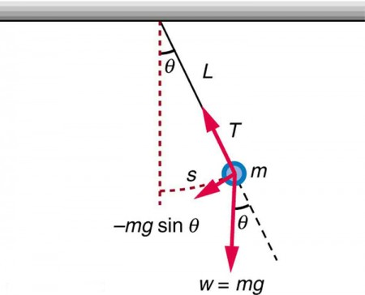

( https://courses.lumenlearning.com/physics/chapter/16-4-the-simple-pendulum/#:~:text=A%20mass%20m%20suspended%20by,the%20acceleration%20due%20to%20gravity )

We plan on showing the angle, theta, verses time as well as the phase space diagram. We are expecting to see a sinusoidal pattern for the angle vs time becuase of the simple, harmonic properties of a single pendulum. For the phase space diagram we want to see the maximum velocity to be at the bottom of the pendulum (no displacement) and minimum velocity at the turning poitn of the pendulum (maximum displacement).

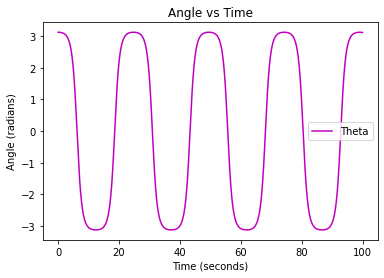

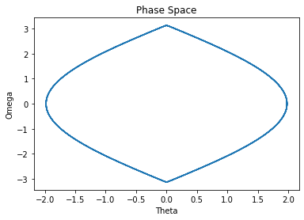

```python
from math import sin, pi, cos                    ## Importingportant Libraries
from pylab import plot, xlabel, show, ylabel, title
from numpy import array, arange
import matplotlib.pyplot as plt

g = 9.8                                          ## Graviational constant (m/s^2)
l = 10                                           ## Length of pendulum arm (m)

def f(r,t):
    theta = r[0]
    omega = r[1]
    ftheta = omega
    fomega = -g/l*sin(theta)
    return array([ftheta, fomega], float)        ## Differential Equation to be solved

a = 0.0                                          ## Lower limit
b = 100                                          ## Upper limit
N = 10000                                        ## Number of steps
h = (b-a)/N                                      ## Width of steps

tpoints = arange(a,b,h)                          ## Array of timepoints to plug into rk4
theta_points = []                                ## Empty list for theta values to fill
omega_points = []                                ## Empty list for omega values to fill

                                                 ## Note: -y direction will be zero; with this setup the counterclockwise
                                                 ##       motion from the -y direction gives a positive angle;
                                                 ##       clockwise motion from the -y direction gives a negative angle

theta_i = 179                                    ## Angle formed from the vertical(degrees)
theta_i_rad = theta_i*pi/180                     ## Convert starting angle into radians
x_i = l*sin(theta_i_rad)                         ## Initial position of x coordinate
y_i = l*cos(theta_i_rad)                         ## Initial position of y coordinate

r = array([theta_i_rad, 0.0], float)
for t in tpoints:
    theta_points.append(r[0])
    omega_points.append(r[1])
    k1 = h*f(r,t)                               ## Runge-Kutta first Order
    k2 = h*f(r + 0.5*k1, t + 0.5*h)             ## Runge-Kutta second order
    k3 = h*f(r + 0.5*k2, t + 0.5*h)             ## Runge-Kutta third order
    k4 = h*f(r + k3, t + h)                     ## Runge-Kutta fourth order
    r += (k1 + 2*k2 + 2*k3 + k4)/6              ## Final evaluation of Runge-Kutta

## Plot Angle vs Time
plot(tpoints, theta_points,'m')                 ## Plot Theta values vs time
xlabel('Time (seconds)')                        ## Label x-axis
ylabel('Angle (radians)')                       ## Label y-axis
title('Angle vs Time')                          ## Add title
labels = ['Theta', 'Omega']                     ## Add a ledgend
plt.legend(labels)
show()

## Plot Phase Space
plot(omega_points, theta_points)                ## Plot Omega points vs time
xlabel('Theta')                                 ## Label x-axis
ylabel('Omega')                                 ## Label y-axis
title('Phase Space')                            ## Add title
show()
```

## Derivation of Double Pendulum

In order to create a code for the double pendulum, we first needed to derive the differential equations of motion as well as the equations for energy.

We begin by first defining the parameters $$x_1=l_1\sin\theta_1$$ $$y_1=-l_1\cos\theta_1$$ $$x_2=l_1\sin\theta_1+l_2\sin\theta_2$$ $$y_2=-l_1\cos\theta_1-l_1\sin\theta_2$$ $$\dot{x}_1=l_1\dot{\theta}_1\cos\theta_1$$ $$\dot{y}_1=l_1\dot{\theta}_1\sin\theta_1$$ $$\dot{x}_2=l_1\dot{\theta}_1\cos\theta_1+l_2\dot{\theta}_2\cos\theta_2$$ $$\dot{y}_2=l_1\dot{\theta}_1\sin\theta_1+l_2\dot{\theta}_2\sin\theta_2$$

We then solve for potential and kinetic energies equations $$V=m_1gy_1+m_2gy_2=-(m_1+m_2)l_1g\cos\theta_1-m_2l_2g\cos\theta_2$$ $$T=\frac{1}{2}m_1v_1^2+\frac{1}{2}m_2v_2^2=\frac{1}{2}m_1(\dot{x}_1^2+\dot{y}_1^2)+\frac{1}{2}m_2(\dot{x}_2^2+\dot{y}_2^2)$$ $$=\frac{1}{2}m_1l_1^2\dot{\theta}_1^2+\frac{1}{2}m_2[l_1^2\dot{\theta}_1^2+l_2^2\dot{\theta}_2^2+2l_1l_2\dot{\theta}_1\dot{\theta}_2\cos(\theta_1-\theta_2)]$$

The Euler-Lagrange Equation $$\frac{d}{dt}(\frac{\partial\mathcal{L}}{\partial\dot{q}_i})-\frac{\partial\mathcal{L}}{\partial q_i}=0$$ for $$q_i=\theta_1,\theta_2$$

$$(m_1+m_2)l_1\ddot{\theta}_1+m_2l_2\ddot{\theta}_2\cos(\theta_1-\theta_2)+m_2l_2\dot{\theta_2^2}\sin(\theta_1-\theta_2)+(m_1+m_2)g\sin\theta_1=0$$$$m_2l_2\ddot{\theta}_2+m_2l_1\ddot{\theta}_1\cos(\theta_1-\theta_2)-m_2l_1\dot{\theta}_1^2\sin(\theta_1-\theta_2)+m_2g\sin\theta_2=0$$

Rearrange the above equations to solve for our equations of motion $$\dot{\omega_1} and \dot{\omega_2}$$ $$\dot{\omega_1}=\frac{m_2g\sin\theta_2\cos(\theta_1-\theta_2)-m_2\sin(\theta_1-\theta_2)[l_1\omega_1^2\cos(\theta_1-\theta_2)+l_2\omega_2^2]-(m_1+m_2)g\sin\theta_1}{l_1[m_1+m_2\sin^2(\theta_1-\theta_2)]}$$ $$\dot{\omega_2}=\frac{(m_1+m_2)[l_1\omega_1^2\sin(\theta_1-\theta_2)-g\sin\theta_2+g\sin\theta_1\cos(\theta_1-\theta_2)]+m_2l_2\omega_2^2\sin(\theta_1-\theta_2)\cos(\theta_1-\theta_2)}{l_2[m_1+m_2\sin^2(\theta_1-\theta_2)]}$$

## Double Pendulum

Now that we have the equations for motion, lets briefly review what we expect to see from a double pendulum. Opposite from the single, perodic pendulum, the double pendulum is completly chaotic, non-predicidable motion.

**Code of Double Pendulum-Total Energy**

This portion of the code hopes to show the principle of conservation of energy. We expect to see the potential and kinetic energies cancel eachother out resulting in a total energy change of zero.

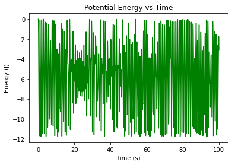

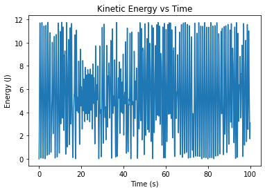

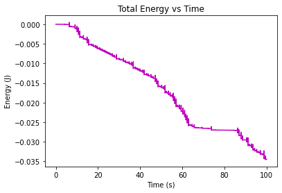

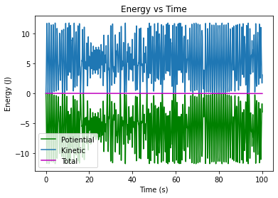

```python
from scipy import array, arange, pi, sin, cos                ## Importing Important Libraries
from pylab import plot, show, xlabel, ylabel, title, legend
from vpython import cylinder, vector, sphere, rate
import numpy as np


g = 9.81                                                     ## Gravity (m/s^2)
m = 1                                                        ## Mass of Pendelums (kg)
l = 0.4                                                      ## Pendulum lengths (m)

theta1_0 = pi/2                                              ## Initial Starting Angle for theta 1 (90 degrees)-Upper Pendulum Angle
theta2_0 = pi/2                                              ## Initial Starting Angle for theta 2 (90 degrees)-Lower Pendulum Angle
omega1_0 = 0                                                 ## Initial Starting Omega 1 value
omega2_0 = 0                                                 ## Initial Starting Omega 2 value

t_0 = 0                                                      ## Lower Limit
t_f = 100                                                    ## Upper Limit
N = 10000                                                    ## Number of Samples
h = (t_f - t_0) / N                                          ## Step Size


def f(r):                                                    ## Define the Differential Equations of the Omegas
    theta1 = r[0]
    omega1 = r[1]
    theta2 = r[2]
    omega2 = r[3]
    f_omega1 = - (omega1 ** 2 * np.sin(2 * theta1 - 2 * theta2) + 2 * omega2 ** 2 * np.sin(theta1 - theta2) + \
                  g / l * (np.sin(theta1 - 2 * theta2) + 3 * np.sin(theta1))) / (3 - np.cos(2 * theta1 - 2 * theta2))
    f_omega2 = (4 * omega1 ** 2 * np.sin(theta1 - theta2) + omega2 ** 2 * np.sin(2 * theta1 - 2 * theta2) + \
                 2 * g / l * (np.sin(2 * theta1 - theta2) - np.sin(theta2))) / (3 - np.cos(2 * theta1 - 2 * theta2))
    return np.array([ omega1, f_omega1, omega2, f_omega2], float)


def energy(r):                                              ## Define Differential Equations for Potential and Kinetic Energy
    theta1 = r[0]
    omega1 = r[1]
    theta2 = r[2]
    omega2 = r[3]
    return - m * g * l * (2 * np.cos(theta1) + np.cos(theta2)), m * l ** 2 * (omega1 ** 2 + 0.5 * omega2 ** 2 + omega1 * omega2 * np.cos(theta1 - theta2))



r = np.array([theta1_0, omega1_0, theta2_0, omega2_0], float)
tpoints = np.arange(t_0, t_f, h)
theta1_points = []                                          ## Empty list for theta 1 values to fill
omega1_points = []                                          ## Empty list for omega 1 values to fill
theta2_points = []                                          ## Empty list for theta 2 values to fill
omega2_points = []                                          ## Empty list for omega 2 values to fil
Tenergy_points = []                                         ## Empty list for Potential energy points to fill
Venergy_points = []                                         ## Empty list for Kinetic energy points to fill
Lenergy_points = []                                         ## Empty list for total energy points to fill


for t in tpoints:
    theta1_points.append(r[0])
    omega1_points.append(r[1])
    theta2_points.append(r[2])
    omega2_points.append(r[3])
    V,T = energy(r)
    Tenergy_points.append(T)
    Venergy_points.append(V)
    Lenergy_points.append(T+V)
    k1 = h * f(r)                                           ## Runge-Kutta first Order
    k2 = h * f(r + 0.5 * k1)                                ## Runge-Kutta second Order
    k3 = h * f(r + 0.5 * k2)                                ## Runge-Kutta third Order
    k4 = h * f(r + k3)                                      ## Runge-Kutta fourth Order
    r += (k1 + 2 * k2 + 2 * k3 + k4) / 6                    ## Final Evaluation of Runge-Kutta

## Plot Energy Graphs
plot(tpoints, Venergy_points,'g')                           ## Plot Potential Energy points
xlabel('Time (s)')                                          ## Label x-axis
ylabel('Energy (J)')                                        ## Label y-axis
title('Potential Energy vs Time')                           ## Add title to graph
show()

plot(tpoints, Tenergy_points)                               ## Plot Kinetic Energy points
xlabel('Time (s)')                                          ## Label x-axis
ylabel('Energy (J)')                                        ## Label y-axis
title('Kinetic Energy vs Time')                             ## Add title to graph
show()

plot(tpoints, Lenergy_points, 'm')                          ## Plot Total Energy points
xlabel('Time (s)')                                          ## Label x-axis
ylabel('Energy (J)')                                        ## Label y-axis
title('Total Energy vs Time')                               ## Add title to graph
show()

plot(tpoints, Venergy_points,'g')                           ## Plot Potential Energy points
plot(tpoints, Tenergy_points)                               ## Plot Kinetic Energy points
plot(tpoints, Lenergy_points, 'm')                          ## Plot Total Energy points
xlabel('Time (s)')                                          ## Label x-axis
ylabel('Energy (J)')                                        ## Label y-axis
title('Energy vs Time')                                     ## Add title to graph
labels = ('Potiential','Kinetic','Total')
legend (labels)
show()
```

Above graphs show the energy change over time. We observe from the top two graphs than potential and kinetic energies seem to cancel eachother out, proving the conservation energy law. However, if we analyze the exact values of total energy over time we can observe that it is not perfectly constant because of the approximate nature of the nature the differential equation solution and it slowly drops over time. We note the total energy loss of the system to be 0.035 J over the course of the first 100 seconds.

**Code of Double Pendulum-Angle vs Time**

To better visualize the double pendulum system, we were curious to see how the angles ot the pendulums changed over the course of the simulation. From what we know about double pendulums, we expect to see the both angles moving in a chaotic, non-predicitable manner.

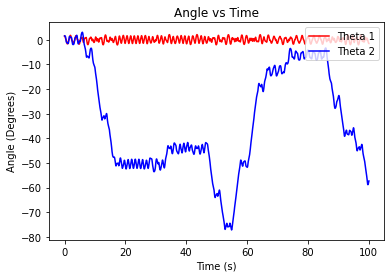

```python
plot(tpoints, theta1_points,'r', label='Theta 1')
plot(tpoints, theta2_points, 'b', label='Theta 2')
xlabel('Time (s)')
ylabel('Angle (Degrees)')
title('Angle vs Time')
legend(loc= 'upper right')
show()
```

We can observe that while the 'top' pendulum osccilates around equilibrium point pretty steadily, yet does not display any harmonic motion. The second pendulum's motion is much more unpredictable and varied with a wider range of angle's values.

**Code of Double Pendulum - Phase Space**

The angle vs time plot above was only able to give us so much information, but we wanted to invistiate how constrained the angles were through the analysis of a phase space plot. We expect to see the top angle be more constrained than the bottom from our observations of the angle vs time plot.

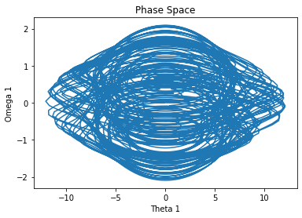

```python
## Plot Phase Space for top angle
plot(omega1_points, theta1_points)                          ## Plot energy points
xlabel('Theta 1')                                           ## Label x-axis
ylabel('Omega 1')                                           ## Label y-axis
title('Phase Space')                                        ## Add title to graph
show()
```

This phase space plot is of the top angle. We can see a "pattern" in the plot. While it is not as clean as the single pendulum, it resembles the same motion. The omega (velocity) is maximized when there is no angluar displacement and is minimized at the turning point (maximum displacment).

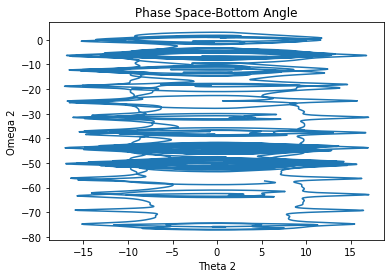

```python
## Plot Phase Space of bottom angle
plot(omega2_points, theta2_points)                          ## Plot energy points
xlabel('Theta 2')                                           ## Label x-axis
ylabel('Omega 2')                                           ## Label y-axis
title('Phase Space-Bottom Angle')                           ## Add title to graph
show()
```

This phase diagram is for the bottom angle. There is no real pattern here implying that the bottom angle is not well constrained.

## Research

For the research part of the project, we plan to analyze how changing the mass and or the length of the pendulums affects the total energy. We expect to see that over the course of the sample, the total energy change will be greater for pendulum of greater length and mass. We are also thinking of looking at how we can visualize the angle change verses time for not only the original double pendulum but the pendulums of different mass and length. In an ideal world the energy change would be zero as the conservation of energy would be in place, but in the real word we do not see this because of the nature of differential equation solution.

**Mass Change from 1 to 50 kg**

This is the same code as the orginial double pendulum above except for the mass change. We expect to see a greater decrease in energy compared to the orginial double pendulum simulation. We do not expect to see much of a change in the angle vs time or the phase space diagrams.

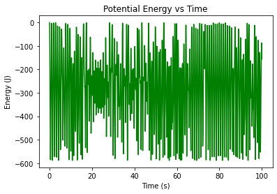

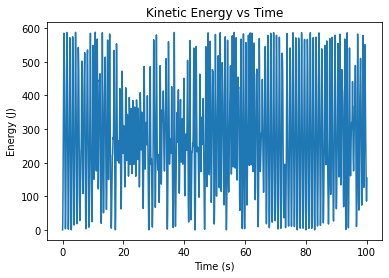

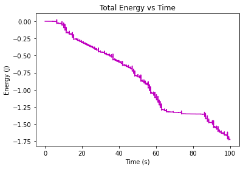

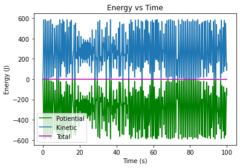

```python
from scipy import array, arange, pi, sin, cos                ## Importing Important Libraries
from pylab import plot, show, xlabel, ylabel, title, legend
from vpython import cylinder, vector, sphere, rate
import numpy as np


g = 9.81                                                     ## Gravity (m/s^2)
m = 50                                                        ## Mass of Pendelums (kg)
l = 0.4                                                      ## Pendulum lengths (m)

theta1_0 = pi / 2                                            ## Initial Starting Angle for theta 1 (90 degrees)-Upper Pendulum Angle
theta2_0 = pi / 2                                            ## Initial Starting Angle for theta 2 (90 degrees)-Lower Pendulum Angle
omega1_0 = 0                                                 ## Initial Starting Omega 1 value
omega2_0 = 0                                                 ## Initial Starting Omega 2 value

t_0 = 0                                                      ## Lower Limit
t_f = 100                                                    ## Upper Limit
N = 10000                                                    ## Number of Samples
h = (t_f - t_0) / N                                          ## Step Size


def f(r):                                                    ## Define the Differential Equations of the Omegas
    theta1 = r[0]
    omega1 = r[1]
    theta2 = r[2]
    omega2 = r[3]
    f_omega1 = - (omega1 ** 2 * np.sin(2 * theta1 - 2 * theta2) + 2 * omega2 ** 2 * np.sin(theta1 - theta2) + \
                  g / l * (np.sin(theta1 - 2 * theta2) + 3 * np.sin(theta1))) / (3 - np.cos(2 * theta1 - 2 * theta2))
    f_omega2 = (4 * omega1 ** 2 * np.sin(theta1 - theta2) + omega2 ** 2 * np.sin(2 * theta1 - 2 * theta2) + \
                 2 * g / l * (np.sin(2 * theta1 - theta2) - np.sin(theta2))) / (3 - np.cos(2 * theta1 - 2 * theta2))
    return np.array([ omega1, f_omega1, omega2, f_omega2], float)


def energy(r):                                              ## Define Differential Equations for Potential and Kinetic Energy
    theta1 = r[0]
    omega1 = r[1]
    theta2 = r[2]
    omega2 = r[3]
    return - m * g * l * (2 * np.cos(theta1) + np.cos(theta2)), m * l ** 2 * (omega1 ** 2 + 0.5 * omega2 ** 2 + omega1 * omega2 * np.cos(theta1 - theta2))



r = np.array([theta1_0, omega1_0, theta2_0, omega2_0], float)
tpoints = np.arange(t_0, t_f, h)
theta1_points = []                                          ## Empty list for theta 1 values to fill
omega1_points = []                                          ## Empty list for omega 1 values to fill
theta2_points = []                                          ## Empty list for theta 2 values to fill
omega2_points = []                                          ## Empty list for omega 2 values to fil
Tenergy_points = []                                         ## Empty list for Potential energy points to fill
Venergy_points = []                                         ## Empty list for Kinetic energy points to fill
Lenergy_points = []                                         ## Empty list for total energy points to fill


for t in tpoints:
    theta1_points.append(r[0])
    omega1_points.append(r[1])
    theta2_points.append(r[2])
    omega2_points.append(r[3])
    V,T = energy(r)
    Tenergy_points.append(T)
    Venergy_points.append(V)
    Lenergy_points.append(T+V)
    k1 = h * f(r)                                           ## Runge-Kutta first Order
    k2 = h * f(r + 0.5 * k1)                                ## Runge-Kutta second Order
    k3 = h * f(r + 0.5 * k2)                                ## Runge-Kutta third Order
    k4 = h * f(r + k3)                                      ## Runge-Kutta fourth Order
    r += (k1 + 2 * k2 + 2 * k3 + k4) / 6                    ## Final Evaluation of Runge-Kutta

## Plot Energy Graphs
plot(tpoints, Venergy_points,'g')                           ## Plot Potential Energy points
xlabel('Time (s)')                                          ## Label x-axis
ylabel('Energy (J)')                                        ## Label y-axis
title('Potential Energy vs Time')                           ## Add title to graph
show()

plot(tpoints, Tenergy_points)                               ## Plot Kinetic Energy points
xlabel('Time (s)')                                          ## Label x-axis
ylabel('Energy (J)')                                        ## Label y-axis
title('Kinetic Energy vs Time')                             ## Add title to graph
show()

plot(tpoints, Lenergy_points, 'm')                          ## Plot Total Energy points
xlabel('Time (s)')                                          ## Label x-axis
ylabel('Energy (J)')                                        ## Label y-axis
title('Total Energy vs Time')                               ## Add title to graph
show()

plot(tpoints, Venergy_points,'g')                           ## Plot Potential Energy points
plot(tpoints, Tenergy_points)                               ## Plot Kinetic Energy points
plot(tpoints, Lenergy_points, 'm')                          ## Plot Total Energy points
xlabel('Time (s)')                                          ## Label x-axis
ylabel('Energy (J)')                                        ## Label y-axis
title('Energy vs Time')                                     ## Add title to graph
labels = ('Potiential','Kinetic','Total')
legend (labels)
show()
```

When there is a change in the masses in a double pendulum, general behaviour (shape) of energy graphs is the same: the potential and kinetic energies sum up to zero and is more or less constant over time (last graph with all energies). However, the range of kinetic and potential energies changes drastically (increase about 50 times). The drop in total energy over time is much bigger as well. It shows how sensitive to initial conditions the double pendulum is.

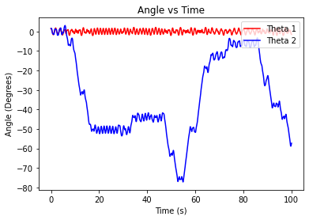

```python
## Plot Angle vs Time
plot(tpoints, theta1_points,'r', label='Theta 1')
plot(tpoints, theta2_points, 'b', label='Theta 2')
xlabel('Time (s)')
ylabel('Angle (Degrees)')
title('Angle vs Time')
legend(loc= 'upper right')
show()
```

This angle vs time plot is very similar to the original just as we expected.

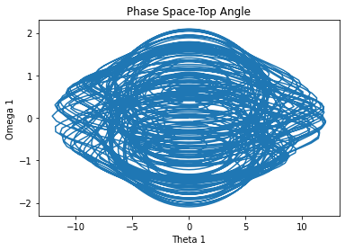

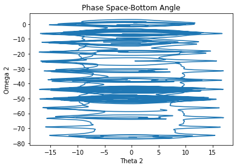

```python
## Plot Phase Space for top angle
plot(omega1_points, theta1_points)                          ## Plot energy points
xlabel('Theta 1')                                           ## Label x-axis
ylabel('Omega 1')                                           ## Label y-axis
title('Phase Space-Top Angle')                              ## Add title to graph
show()

## Plot Phase Space for bottom angle
plot(omega2_points, theta2_points)                          ## Plot energy points
xlabel('Theta 2')                                           ## Label x-axis
ylabel('Omega 2')                                           ## Label y-axis
title('Phase Space-Bottom Angle')                           ## Add title to graph
show()
```

The phase space diagrams do not show any drastic changes from the orignal, just as we expected. These phase space diagrams reinforce a our common knowledge of simple pendulums, changing the mass of the pendulum does not affect the period of a simple pendulum.

**Length Change from 0.4 to 1 m**

This is the same code as the orginial double pendulum above except for the length change. We expect to see a greater decrease in energy compared to the orginial double pendulum simulation. We do not expect to see much of a change in the angle vs time or the phase space diagrams.

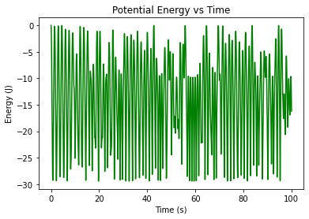

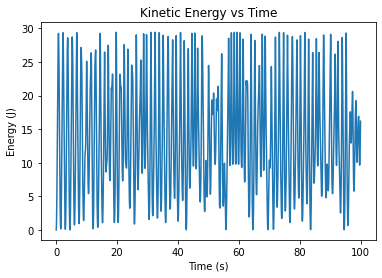

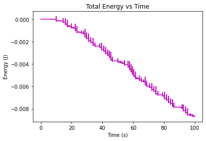

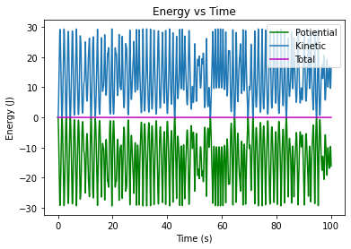

```python
from scipy import array, arange, pi, sin, cos                ## Importing Important Libraries
from pylab import plot, show, xlabel, ylabel, title, legend
from vpython import cylinder, vector, sphere, rate
import numpy as np


g = 9.81                                                     ## Gravity (m/s^2)
m = 1                                                        ## Mass of Pendelums (kg)
l = 1                                                        ## Pendulum lengths (m)

theta1_0 = pi / 2                                            ## Initial Starting Angle for theta 1 (90 degrees)-Upper Pendulum Angle
theta2_0 = pi / 2                                            ## Initial Starting Angle for theta 2 (90 degrees)-Lower Pendulum Angle
omega1_0 = 0                                                 ## Initial Starting Omega 1 value
omega2_0 = 0                                                 ## Initial Starting Omega 2 value

t_0 = 0                                                      ## Lower Limit
t_f = 100                                                    ## Upper Limit
N = 10000                                                    ## Number of Samples
h = (t_f - t_0) / N                                          ## Step Size


def f(r):                                                    ## Define the Differential Equations of the Omegas
    theta1 = r[0]
    omega1 = r[1]
    theta2 = r[2]
    omega2 = r[3]
    f_omega1 = - (omega1 ** 2 * np.sin(2 * theta1 - 2 * theta2) + 2 * omega2 ** 2 * np.sin(theta1 - theta2) + \
                  g / l * (np.sin(theta1 - 2 * theta2) + 3 * np.sin(theta1))) / (3 - np.cos(2 * theta1 - 2 * theta2))
    f_omega2 = (4 * omega1 ** 2 * np.sin(theta1 - theta2) + omega2 ** 2 * np.sin(2 * theta1 - 2 * theta2) + \
                 2 * g / l * (np.sin(2 * theta1 - theta2) - np.sin(theta2))) / (3 - np.cos(2 * theta1 - 2 * theta2))
    return np.array([ omega1, f_omega1, omega2, f_omega2], float)


def energy(r):                                              ## Define Differential Equations for Potential and Kinetic Energy
    theta1 = r[0]
    omega1 = r[1]
    theta2 = r[2]
    omega2 = r[3]
    return - m * g * l * (2 * np.cos(theta1) + np.cos(theta2)), m * l ** 2 * (omega1 ** 2 + 0.5 * omega2 ** 2 + omega1 * omega2 * np.cos(theta1 - theta2))



r = np.array([theta1_0, omega1_0, theta2_0, omega2_0], float)
tpoints = np.arange(t_0, t_f, h)
theta1_points = []                                          ## Empty list for theta 1 values to fill
omega1_points = []                                          ## Empty list for omega 1 values to fill
theta2_points = []                                          ## Empty list for theta 2 values to fill
omega2_points = []                                          ## Empty list for omega 2 values to fil
Tenergy_points = []                                         ## Empty list for Potential energy points to fill
Venergy_points = []                                         ## Empty list for Kinetic energy points to fill
Lenergy_points = []                                         ## Empty list for total energy points to fill


for t in tpoints:
    theta1_points.append(r[0])
    omega1_points.append(r[1])
    theta2_points.append(r[2])
    omega2_points.append(r[3])
    V,T = energy(r)
    Tenergy_points.append(T)
    Venergy_points.append(V)
    Lenergy_points.append(T+V)
    k1 = h * f(r)                                           ## Runge-Kutta first Order
    k2 = h * f(r + 0.5 * k1)                                ## Runge-Kutta second Order
    k3 = h * f(r + 0.5 * k2)                                ## Runge-Kutta third Order
    k4 = h * f(r + k3)                                      ## Runge-Kutta fourth Order
    r += (k1 + 2 * k2 + 2 * k3 + k4) / 6                    ## Final Evaluation of Runge-Kutta

## Plot Energy Graphs
plot(tpoints, Venergy_points,'g')                           ## Plot Potential Energy points
xlabel('Time (s)')                                          ## Label x-axis
ylabel('Energy (J)')                                        ## Label y-axis
title('Potential Energy vs Time')                           ## Add title to graph
show()

plot(tpoints, Tenergy_points)                               ## Plot Kinetic Energy points
xlabel('Time (s)')                                          ## Label x-axis
ylabel('Energy (J)')                                        ## Label y-axis
title('Kinetic Energy vs Time')                             ## Add title to graph
show()

plot(tpoints, Lenergy_points, 'm')                          ## Plot Total Energy points
xlabel('Time (s)')                                          ## Label x-axis
ylabel('Energy (J)')                                        ## Label y-axis
title('Total Energy vs Time')                               ## Add title to graph
show()

plot(tpoints, Venergy_points,'g')                           ## Plot Potential Energy points
plot(tpoints, Tenergy_points)                               ## Plot Kinetic Energy points
plot(tpoints, Lenergy_points, 'm')                          ## Plot Total Energy points
xlabel('Time (s)')                                          ## Label x-axis
ylabel('Energy (J)')                                        ## Label y-axis
title('Energy vs Time')                                     ## Add title to graph
labels = ('Potiential','Kinetic','Total')
legend (labels)
show()
```

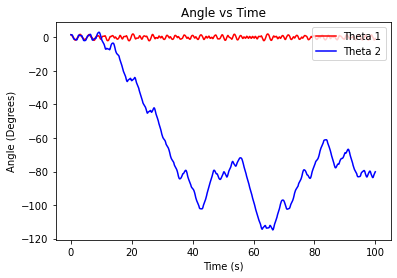

```python
## Plot Angle vs Time
plot(tpoints, theta1_points,'r', label='Theta 1')
plot(tpoints, theta2_points, 'b', label='Theta 2')
xlabel('Time (s)')
ylabel('Angle (Degrees)')
title('Angle vs Time')
legend(loc= 'upper right')
show()
```

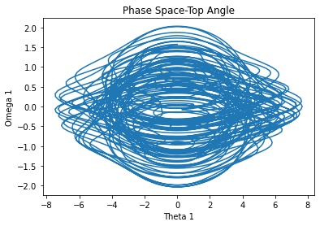

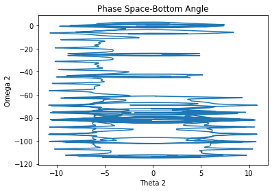

```python
## Plot Phase Space for top angle
plot(omega1_points, theta1_points)                          ## Plot energy points
xlabel('Theta 1')                                           ## Label x-axis
ylabel('Omega 1')                                           ## Label y-axis
title('Phase Space-Top Angle')                              ## Add title to graph
show()

## Plot Phase Space for bottom angle
plot(omega2_points, theta2_points)                          ## Plot Omega2 points vs Theta 1 points
xlabel('Theta 2')                                           ## Label x-axis
ylabel('Omega 2')                                           ## Label y-axis
title('Phase Space-Bottom Angle')                           ## Add title to graph
show()
```

The top phase space diagram is very similar to the original, but is slightly "less tight" implying a longer period, which makes since pulling from out knowledge of simple pendulums, the period of the pendulum is only affected by the length of the rod and the acceleration due to gravity.

The bottom phase space diagram resembles a similar pattern, minus the range of velocities (0-120 vs 0-80) and some differing patterens in the 20-80 range of Omega two.

## Conclusion

Through this coding project, we explored the Runge-kutta method of analyzing differential equations, specifically those of the single and double pendulum. We looked at how the conservation of energy law applied with varing parameters such as mass and length changes. We found that the energy changes were due to the nature of the Runge-kutta method, if we were to have used Verlot or Leapfrog we would expect to see a smaller drift in energy. We also learned how to create phase space plots and how to interpert them. We applied our general knowledge of single pendulums to help us interpert some of the patterns and changes we observed.